# Chile Voting Predictor

RP

June 2, 2019

## Chile Voting Predictor Introduction

The Voting predictor is build for Chile Population based on the `Chile` dataset. This dataset contains following information:

- **region** : A factor with levels: `C` Central `M` Metropolitan Santiago area `N` North `S` South `SA` city of Santiago.
- **population** : Population size of respondent’s community.
- **sex** : A factor with levels: `F` female `M` male.
- **age** : in years.
- **education** : A factor with levels (note: out of order): `P` Primary `PS` Post-secondary `S` Secondary.
- **income** : Monthly income, in Pesos.
- **statusquo** : Scale of support for the status-quo.
- **vote** : a factor with levels: `A` will abstain `N` will vote no (against Pinochet) `U` undecided `Y` will vote yes (for Pinochet).

## Prediction Model

- App is built using Shiny server and deployed on Shiny apps.
- `ui.R` and `server.R` code is stored on github repository.
- This presentation is build using R Slidify option. code is stored in github Repository.
- `server.R` contains 2 functions:
1. `chile_predict` function : This function runs the randomforest classification after data cleansing and predicts what action voter will take.
2. `chile_plot` function : This function plots existing pattern of Chile voter and then using classification current voter prediction is displayed.

## Slide link for Github Repository

### ui.R and server.R code is stored in Github Repository : https://github.com/ravinderpratap/Course9_week3_assignment in Chile_Voting_Predictor Folder

## Slide link for shiny Apps

### Shiny App webpage : https://rpsingh85.shinyapps.io/Chile_Voting_Predictor/

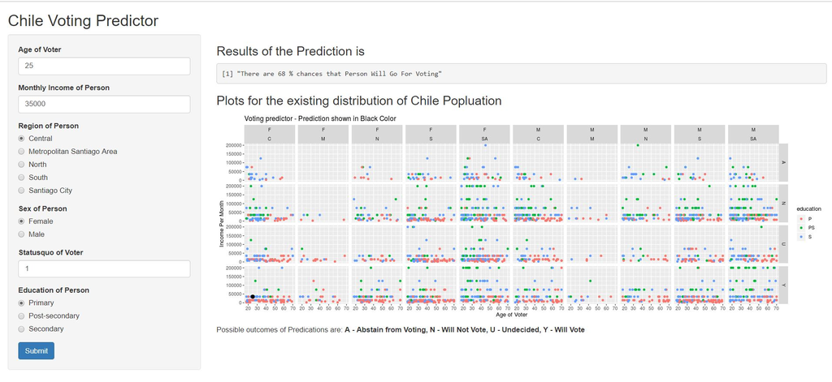

screenshot